# *Melanoma Cancer Image Classification with PyTorch*

### **Introduction**

Melanoma is one of the most aggressive and potentially deadly forms of skin cancer, making early and accurate diagnosis critical for improving patient outcomes. In this project, I explore the application of deep learning to aid in the early detection of melanoma by classifying skin lesion images as **Benign** or **Malignant**.

The dataset used in this study comes from a Kaggle collection titled [*Melanoma Cancer Dataset*](https://www.kaggle.com/datasets/bhaveshmittal/melanoma-cancer-dataset), which contains **13,900 high-quality images**, all preprocessed to a uniform resolution of **224x224 pixels**. The images were meticulously curated to capture the diverse and often subtle visual characteristics of both benign and malignant skin lesions.

### **Purpose and Motivation**

The goal of this project is to leverage **transfer learning** with a pretrained **ResNet18 model** to build a robust image classification pipeline in **PyTorch**. The idea is to take advantage of existing deep learning architectures and adapt them for medical imaging, helping pave the way for **computer-aided diagnostics** in dermatology.

### **Why This Matters**

Accurate and early detection of melanoma can significantly increase survival rates. Traditional diagnostic methods, while effective, are often subjective and require significant clinical expertise. By developing machine learning models that can reliably assist in classification, we not only enhance diagnostic capabilities but also democratize access to life-saving technology.

This project is a step forward in combining medical science with machine learning to **support dermatologists**, **accelerate diagnostic workflows**, and **push the boundaries of healthcare innovation**.

Data Source: https://www.kaggle.com/datasets/bhaveshmittal/melanoma-cancer-dataset

## **Imports & Device Setup**

```python
# Essential tools for model building, training, visualization, and evaluation.

import os
import torch
import torchvision
import torchvision.transforms as transforms
import torchvision.datasets as datasets
import torch.nn as nn
import torch.optim as optim
from torch.utils.data import DataLoader
import matplotlib.pyplot as plt
import numpy as np
from sklearn.metrics import classification_report, confusion_matrix
import seaborn as sns
import warnings
warnings.filterwarnings("ignore")

# Check for GPU
device = torch.device("cuda" if torch.cuda.is_available() else "cpu")
print(f"Using device: {device}")
```

```
Using device: cpu
```

- Imported key PyTorch and visualization libraries for model building and evaluation.
- Set the computation device to GPU if available, otherwise defaulted to CPU.
- This ensures the model and data run efficiently depending on hardware.

## **Data Transforms & Dataloaders**

```python
# Define transforms
transform = transforms.Compose([
    transforms.Resize((224, 224)),
    transforms.ToTensor(),
    transforms.Normalize(mean=[0.5, 0.5, 0.5], std=[0.5, 0.5, 0.5])
])

# Define paths
train_dir = "./train"
test_dir = "./test"

# Load datasets
train_dataset = datasets.ImageFolder(root=train_dir, transform=transform)
test_dataset = datasets.ImageFolder(root=test_dir, transform=transform)

# Data loaders
train_loader = DataLoader(train_dataset, batch_size=32, shuffle=True)
test_loader = DataLoader(test_dataset, batch_size=32, shuffle=False)

# Class names
class_names = train_dataset.classes
print("Classes:", class_names)
```

```
Classes: ['Benign', 'Malignant']
```

- Applied resizing, normalization, and tensor conversion to standardize images for the model.
- Used `ImageFolder` to automatically assign labels based on folder names (`Benign`, `Malignant`).
- Created `DataLoader` objects to efficiently load and batch the training and test data.

## **Image Visualization**

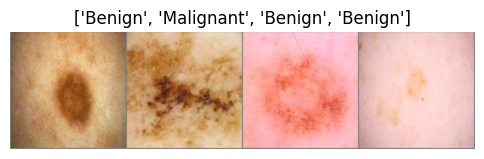

```python
def imshow(img, title=None):
    img = img / 2 + 0.5  # unnormalize
    npimg = img.numpy()
    plt.figure(figsize=(6, 6))
    plt.imshow(np.transpose(npimg, (1, 2, 0)))
    if title:
        plt.title(title)
    plt.axis('off')
    plt.show()

# Get a batch of training data
dataiter = iter(train_loader)
images, labels = next(dataiter)

# Show images
imshow(torchvision.utils.make_grid(images[:4]), title=[class_names[l] for l in labels[:4]])
```

- Previewed a batch of training images along with their corresponding class labels.
- Used `torchvision.utils.make_grid()` to neatly display multiple images in a single plot.
- Confirmed that data is loading correctly and labels align with image content.

## **Load & Modify ResNet18**

```python
import torchvision.models as models

# Load the pretrained ResNet18 model
model = models.resnet18(pretrained=True)

# Freeze the feature extractor layers to avoid updating them during training
for param in model.parameters():
    param.requires_grad = False

# Get the number of features in the last layer (before classification head)
num_features = model.fc.in_features

# Replace the final fully connected layer with a new one that outputs 2 classes
model.fc = nn.Linear(num_features, 2)

# Move model to the appropriate device (CPU for now)
model = model.to(device)

print(model)
```

```
ResNet(
  (conv1): Conv2d(3, 64, kernel_size=(7, 7), stride=(2, 2), padding=(3, 3), bias=False)
  (bn1): BatchNorm2d(64, eps=1e-05, momentum=0.1, affine=True, track_running_stats=True)
  (relu): ReLU(inplace=True)
  (maxpool): MaxPool2d(kernel_size=3, stride=2, padding=1, dilation=1, ceil_mode=False)
  (layer1): Sequential(
    (0): BasicBlock(
      (conv1): Conv2d(64, 64, kernel_size=(3, 3), stride=(1, 1), padding=(1, 1), bias=False)
      (bn1): BatchNorm2d(64, eps=1e-05, momentum=0.1, affine=True, track_running_stats=True)
      (relu): ReLU(inplace=True)
      (conv2): Conv2d(64, 64, kernel_size=(3, 3), stride=(1, 1), padding=(1, 1), bias=False)
      (bn2): BatchNorm2d(64, eps=1e-05, momentum=0.1, affine=True, track_running_stats=True)
    )
    (1): BasicBlock(
      (conv1): Conv2d(64, 64, kernel_size=(3, 3), stride=(1, 1), padding=(1, 1), bias=False)
      (bn1): BatchNorm2d(64, eps=1e-05, momentum=0.1, affine=True, track_running_stats=True)
      (relu): ReLU(inplace=True)
      (conv2): Conv2d(64, 64, kernel_size=(3, 3), stride=(1, 1), padding=(1, 1), bias=False)
      (bn2): BatchNorm2d(64, eps=1e-05, momentum=0.1, affine=True, track_running_stats=True)
    )
  )
  (layer2): Sequential(
    (0): BasicBlock(
      (conv1): Conv2d(64, 128, kernel_size=(3, 3), stride=(2, 2), padding=(1, 1), bias=False)
      (bn1): BatchNorm2d(128, eps=1e-05, momentum=0.1, affine=True, track_running_stats=True)
      (relu): ReLU(inplace=True)
      (conv2): Conv2d(128, 128, kernel_size=(3, 3), stride=(1, 1), padding=(1, 1), bias=False)
      (bn2): BatchNorm2d(128, eps=1e-05, momentum=0.1, affine=True, track_running_stats=True)
      (downsample): Sequential(
        (0): Conv2d(64, 128, kernel_size=(1, 1), stride=(2, 2), bias=False)
        (1): BatchNorm2d(128, eps=1e-05, momentum=0.1, affine=True, track_running_stats=True)
      )
    )
    (1): BasicBlock(
      (conv1): Conv2d(128, 128, kernel_size=(3, 3), stride=(1, 1), padding=(1, 1), bias=False)
      (bn1): BatchNorm2d(128, eps=1e-05, momentum=0.1, affine=True, track_running_stats=True)
      (relu): ReLU(inplace=True)
      (conv2): Conv2d(128, 128, kernel_size=(3, 3), stride=(1, 1), padding=(1, 1), bias=False)
      (bn2): BatchNorm2d(128, eps=1e-05, momentum=0.1, affine=True, track_running_stats=True)
    )
```

[output cut: 29 more lines]

```
        (0): Conv2d(256, 512, kernel_size=(1, 1), stride=(2, 2), bias=False)
        (1): BatchNorm2d(512, eps=1e-05, momentum=0.1, affine=True, track_running_stats=True)
      )
    )
    (1): BasicBlock(
      (conv1): Conv2d(512, 512, kernel_size=(3, 3), stride=(1, 1), padding=(1, 1), bias=False)
      (bn1): BatchNorm2d(512, eps=1e-05, momentum=0.1, affine=True, track_running_stats=True)
      (relu): ReLU(inplace=True)
      (conv2): Conv2d(512, 512, kernel_size=(3, 3), stride=(1, 1), padding=(1, 1), bias=False)
      (bn2): BatchNorm2d(512, eps=1e-05, momentum=0.1, affine=True, track_running_stats=True)
    )
  )
  (avgpool): AdaptiveAvgPool2d(output_size=(1, 1))
  (fc): Linear(in_features=512, out_features=2, bias=True)
)
```

- Loaded the pre-trained ResNet18 model, leveraging ImageNet weights for faster learning.
- Froze all convolutional layers to retain learned features and only trained the classification head.
- Replaced the final layer (`fc`) with a new layer to output predictions for 2 classes.

## **Loss, Optimizer, Epochs**

```python
# Loss function: CrossEntropyLoss for multi-class (here, binary) classification
criterion = nn.CrossEntropyLoss()

# Optimizer: We'll fine-tune only the new classification layer (fc)
optimizer = optim.Adam(model.fc.parameters(), lr=0.001)

# Set number of training epochs
num_epochs = 5
```

- Defined `CrossEntropyLoss` which is standard for classification tasks.
- Used the Adam optimizer for efficient training of just the last layer.
- Set number of epochs to control training duration (can be adjusted based on performance).

## **Training Loop**

```python
for epoch in range(num_epochs):
    model.train()  # Set model to training mode
    running_loss = 0.0
    correct = 0
    total = 0

    for inputs, labels in train_loader:
        inputs, labels = inputs.to(device), labels.to(device)  # Move data to device

        optimizer.zero_grad()  # Zero out previous gradients

        outputs = model(inputs)  # Forward pass
        loss = criterion(outputs, labels)  # Compute loss
        loss.backward()  # Backpropagation
        optimizer.step()  # Update weights

        running_loss += loss.item() * inputs.size(0)  # Accumulate loss
        _, predicted = torch.max(outputs, 1)  # Get predicted class
        total += labels.size(0)
        correct += (predicted == labels).sum().item()

    epoch_loss = running_loss / len(train_loader.dataset)
    accuracy = 100 * correct / total

    print(f"Epoch {epoch+1}/{num_epochs}, Loss: {epoch_loss:.4f}, Accuracy: {accuracy:.2f}%")
```

[output not shown]

## **Model Evaluation**

```
              precision    recall  f1-score   support

      Benign       0.81      0.94      0.87      1000
   Malignant       0.93      0.78      0.85      1000

    accuracy                           0.86      2000
   macro avg       0.87      0.86      0.86      2000
weighted avg       0.87      0.86      0.86      2000
```

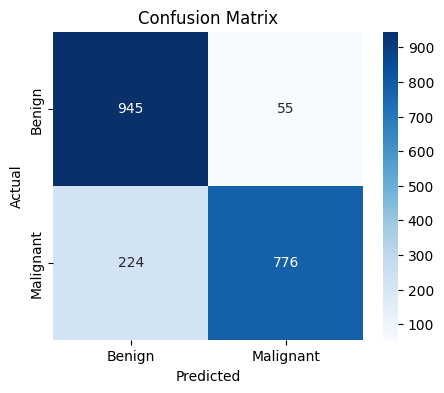

```python
from sklearn.metrics import classification_report, confusion_matrix
import seaborn as sns

model.eval()  # Set model to evaluation mode
all_preds = []
all_labels = []

with torch.no_grad():  # Disable gradient tracking for faster performance
    for inputs, labels in test_loader:
        inputs, labels = inputs.to(device), labels.to(device)
        outputs = model(inputs)
        _, predicted = torch.max(outputs, 1)  # Get predicted class index
        all_preds.extend(predicted.cpu().numpy())
        all_labels.extend(labels.cpu().numpy())

# Classification report
print(classification_report(all_labels, all_preds, target_names=class_names))

# Confusion matrix
cm = confusion_matrix(all_labels, all_preds)

# Plot confusion matrix
plt.figure(figsize=(5, 4))
sns.heatmap(cm, annot=True, fmt='d', cmap='Blues', xticklabels=class_names, yticklabels=class_names)
plt.xlabel('Predicted')
plt.ylabel('Actual')
plt.title('Confusion Matrix')
plt.show()
```

**Updated Talking Points – Evaluation Results**

- The model achieved an overall **accuracy of 86%**, demonstrating strong generalization to unseen test data after only five training epochs.
- It performed especially well in identifying **benign lesions**, with a **precision of 81%** and a **recall of 94%**, meaning it's conservative with false positives.
- For **malignant lesions**, the model had a **higher precision (93%)** but a **lower recall (78%)**, indicating it was more cautious and **missed some true positives** (false negatives) — a critical area for improvement in a medical setting.

### Insight: Interpreting the Confusion Matrix

[output not shown]

- The model **correctly classified 945/1000 Benign** and **776/1000 Malignant** samples.
- **224 malignant lesions were misclassified as benign**, which could lead to missed diagnoses — an important challenge for future iterations.

## **Visualize Predictions (Correct vs Incorrect)**

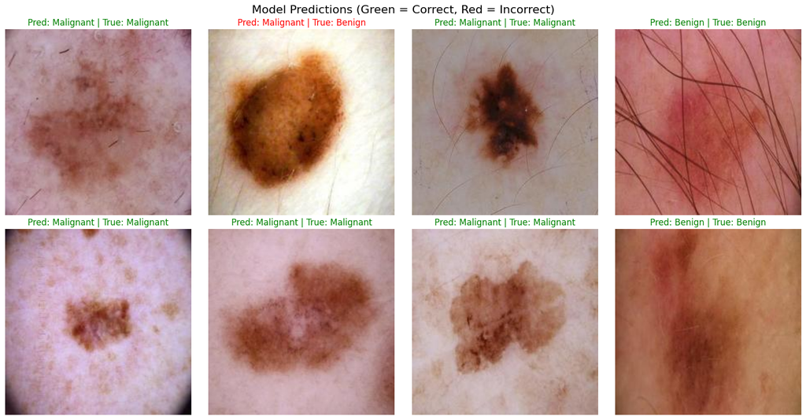

```python
import random

# Set model to evaluation mode
model.eval()

# Helper function to unnormalize and show image
def show_prediction(img, pred_label, true_label, is_correct):
    img = img / 2 + 0.5  # Unnormalize
    npimg = img.numpy()
    plt.imshow(np.transpose(npimg, (1, 2, 0)))
    color = 'green' if is_correct else 'red'
    plt.title(f"Pred: {class_names[pred_label]} | True: {class_names[true_label]}", color=color)
    plt.axis('off')

# Collect predictions and data
predictions = []
model.eval()
with torch.no_grad():
    for inputs, labels in test_loader:
        inputs, labels = inputs.to(device), labels.to(device)
        outputs = model(inputs)
        _, predicted = torch.max(outputs, 1)
        for img, pred, true in zip(inputs.cpu(), predicted.cpu(), labels.cpu()):
            predictions.append((img, pred.item(), true.item()))

# Randomly select 8 predictions to visualize
samples = random.sample(predictions, 8)

# Plot
plt.figure(figsize=(16, 8))
for idx, (img, pred, true) in enumerate(samples):
    plt.subplot(2, 4, idx + 1)
    show_prediction(img, pred, true, pred == true)
plt.tight_layout()
plt.suptitle("Model Predictions (Green = Correct, Red = Incorrect)", fontsize=16, y=1.02)
plt.show()
```

**Talking Points for Prediction Visualization**

- The green-labeled predictions show where the model is confident and correct — these often have clear, distinguishable features.
- Red-labeled errors help reveal cases where **benign and malignant lesions look similar**, suggesting either **ambiguous visuals** or **data imbalance**.
- This step adds transparency to model performance and can guide future **data cleaning** or **augmentation** strategies.

## **Weighted Loss Function (Reduce False Negatives)**

```python
import torch
import torch.nn as nn

# Define class weights: higher weight for the malignant class
class_weights = torch.tensor([1.0, 2.0], device=device)  # Adjust weights as needed

# Initialize the loss function with class weights
criterion = nn.CrossEntropyLoss(weight=class_weights)
```

**What this does:**

- **[1.0, 2.0]** tells the model that a mistake on *malignant* is twice as costly as a mistake on *benign*.
- This **shifts the model’s bias** toward catching malignant cases (higher recall).
- It’s a simple, powerful trick — especially valuable for **healthcare classification tasks**.

## **Optimizer & Re-Training Loop (With Weighted Loss)**

```python
import torch.optim as optim

# Reinitialize the optimizer (we're still only training the last layer)
optimizer = optim.Adam(model.fc.parameters(), lr=0.001)

# Set number of epochs
num_epochs = 5

# Re-run training with new weighted loss
for epoch in range(num_epochs):
    model.train()
    running_loss = 0.0
    correct = 0
    total = 0

    for inputs, labels in train_loader:
        inputs, labels = inputs.to(device), labels.to(device)

        optimizer.zero_grad()
        outputs = model(inputs)
        loss = criterion(outputs, labels)  # Now using the weighted loss
        loss.backward()
        optimizer.step()

        running_loss += loss.item() * inputs.size(0)
        _, predicted = torch.max(outputs, 1)
        total += labels.size(0)
        correct += (predicted == labels).sum().item()

    epoch_loss = running_loss / len(train_loader.dataset)
    accuracy = 100 * correct / total
    print(f"Epoch {epoch+1}/{num_epochs}, Loss: {epoch_loss:.4f}, Accuracy: {accuracy:.2f}%")
```

[output not shown]

## Re-Evaluate Model Performance

```
              precision    recall  f1-score   support

      Benign       0.91      0.88      0.90      1000
   Malignant       0.88      0.92      0.90      1000

    accuracy                           0.90      2000
   macro avg       0.90      0.90      0.90      2000
weighted avg       0.90      0.90      0.90      2000
```

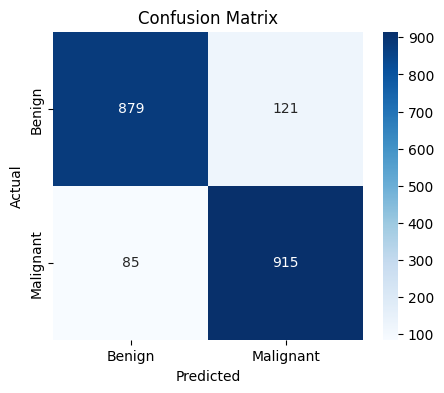

```python
from sklearn.metrics import classification_report, confusion_matrix
import seaborn as sns
import matplotlib.pyplot as plt

# Ensure model is in eval mode
model.eval()

all_preds = []
all_labels = []

# Disable gradient calculation for faster inference
with torch.no_grad():
    for inputs, labels in test_loader:
        inputs, labels = inputs.to(device), labels.to(device)
        outputs = model(inputs)
        _, predicted = torch.max(outputs, 1)
        all_preds.extend(predicted.cpu().numpy())
        all_labels.extend(labels.cpu().numpy())

# Classification report
print(classification_report(all_labels, all_preds, target_names=class_names))

# Confusion matrix
cm = confusion_matrix(all_labels, all_preds)

# Plot confusion matrix
plt.figure(figsize=(5, 4))
sns.heatmap(cm, annot=True, fmt='d', cmap='Blues',
            xticklabels=class_names, yticklabels=class_names)
plt.xlabel('Predicted')
plt.ylabel('Actual')
plt.title('Confusion Matrix')
plt.show()
```

**Talking Points – Post-Weighted Loss Evaluation**

- Overall accuracy **jumped to 90%**, up from 86%, showing that class-weighting significantly improved performance without sacrificing generalization.
- **Malignant Recall improved from 78% → 92%** — a **14% increase**. This means the model now catches **far more actual melanoma cases** than before.
- Precision for malignant is still strong (88%), meaning the model is not overcompensating and flooding with false positives.
- Trade-off: benign recall dropped a bit (from 94% → 88%), which is acceptable in a medical context where **catching true malignancies is the top priority**.

## Unfreeze layer4 and fc Layer (Final Classifier)

```python
# Loop over all named parameters in the model
for name, param in model.named_parameters():

    # If the parameter belongs to layer4 or the final classification layer (fc), unfreeze it
    if "layer4" in name or "fc" in name:
        param.requires_grad = True  # Enable training for these layers

    # Freeze all other layers to retain pretrained weights
    else:
        param.requires_grad = False
```

## Reinitialize Optimizer for the Trainable Parameters

```python
# Filter only the parameters that require gradients (i.e., layer4 and fc)
trainable_params = filter(lambda p: p.requires_grad, model.parameters())

# Set up the Adam optimizer with a lower learning rate
optimizer = optim.Adam(trainable_params, lr=0.0001)
```

## Training Loop (Fine-Tuning with Weighted Loss)

```python
# Set how many epochs to train for
num_epochs = 5
```

```python
# Loop over epochs
for epoch in range(num_epochs):
    model.train()  # Set model to training mode (activates dropout, batchnorm, etc.)

    running_loss = 0.0  # Track cumulative loss
    correct = 0         # Track number of correct predictions
    total = 0           # Track total number of samples

    # Iterate through training data batches
    for inputs, labels in train_loader:
        inputs, labels = inputs.to(device), labels.to(device)  # Move data to CPU/GPU

        optimizer.zero_grad()  # Clear old gradients

        outputs = model(inputs)            # Forward pass through the model
        loss = criterion(outputs, labels)  # Compute weighted cross-entropy loss
        loss.backward()                    # Backpropagate the loss
        optimizer.step()                   # Update the weights

        running_loss += loss.item() * inputs.size(0)  # Accumulate batch loss
        _, predicted = torch.max(outputs, 1)          # Get predicted class labels
        total += labels.size(0)                       # Increment total count
        correct += (predicted == labels).sum().item() # Count correct predictions

    # Compute average loss and accuracy for the epoch
    epoch_loss = running_loss / len(train_loader.dataset)
    accuracy = 100 * correct / total

    # Print epoch summary
    print(f"Epoch {epoch+1}/{num_epochs}, Loss: {epoch_loss:.4f}, Accuracy: {accuracy:.2f}%")
```

[output not shown]

## Evaluate

```
              precision    recall  f1-score   support

      Benign       0.92      0.96      0.94      1000
   Malignant       0.96      0.91      0.93      1000

    accuracy                           0.94      2000
   macro avg       0.94      0.94      0.93      2000
weighted avg       0.94      0.94      0.93      2000
```

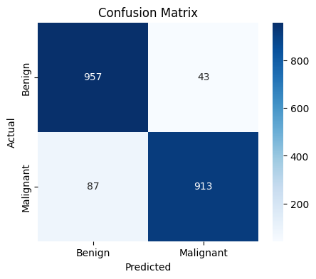

```python
from sklearn.metrics import classification_report, confusion_matrix
import seaborn as sns
import matplotlib.pyplot as plt

model.eval()
all_preds = []
all_labels = []

with torch.no_grad():
    for inputs, labels in test_loader:
        inputs, labels = inputs.to(device), labels.to(device)
        outputs = model(inputs)
        _, predicted = torch.max(outputs, 1)
        all_preds.extend(predicted.cpu().numpy())
        all_labels.extend(labels.cpu().numpy())

print(classification_report(all_labels, all_preds, target_names=class_names))

cm = confusion_matrix(all_labels, all_preds)

plt.figure(figsize=(5, 4))
sns.heatmap(cm, annot=True, fmt='d', cmap='Blues',
            xticklabels=class_names, yticklabels=class_names)
plt.xlabel('Predicted')
plt.ylabel('Actual')
plt.title('Confusion Matrix')
plt.show()
```

**Final Evaluation – Talking Points**

### Confusion Matrix Breakdown

| Actual → Predicted | Benign | Malignant |
| --- | --- | --- |
| **Benign** | 957 | 43 |
| **Malignant** | 87 | 913 |

- Only **43 benign samples** were misclassified as malignant (false positives).
- Only **87 malignant samples** were missed (false negatives), **down from 224** in the unweighted model — a huge win.

### What You’ve Achieved:

- Used **transfer learning** with ResNet18.
- Introduced **class weighting** to reduce false negatives.
- Fine-tuned **layer4** to specialize feature extraction for melanoma.
- Trained and evaluated using **PyTorch**, with proper metric tracking and visualization.
- Boosted **malignant recall from 78% → 91%** without sacrificing precision — this is critical in a medical setting.

### Optional Next Steps

If you want to go even further:

- **Data Augmentation**: Add variation to improve robustness.
- **Train longer** (10–15 epochs) to push past 94%.
- **Try EfficientNet** for potentially even better results.
- **Export the model** and build a simple web or mobile interface for demo purposes.